# Experiment 2 Analysis

### Averages

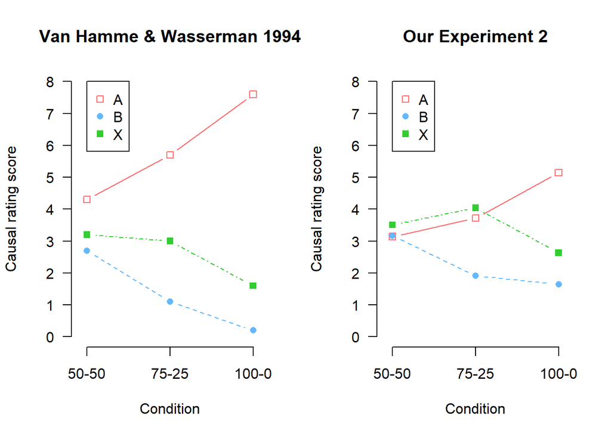

```r
par(mfrow = c(1,2))
par(las=1)
#original plot
emptyPlot(c(-5,105),c(0,8), xaxt = "none", ymark=c(0,1,2,3,4,5,6,7,8), bty='n', main = "Van Hamme & Wasserman 1994", xlab = "Condition", ylab = "Causal rating score")
A <- c(4.3,5.7,7.6)
B <- c(2.7, 1.1, 0.2)
X <- c(3.2,3,1.6)
points(c(0, 50, 100),A, pch = 0, type = "b", col = "indianred1")
points(c(0, 50, 100),B, pch =16, type = "b", lty = 2, col = "steelblue1")
points(c(0, 50, 100),X, pch =15, type = "b", lty = 4, col = "limegreen")
legend(0.05,8,legend =c("A", "B", "X"), pch = c(0,16,15), col = c("indianred1", "steelblue1", "limegreen"))
axis(1, at = c(0,50,100), labels = c("50-50", "75-25", "100-0"))

emptyPlot(c(-5,105),c(0,8), xaxt = "none", ymark=c(0,1,2,3,4,5,6,7,8), bty='n', main = "Our Experiment 2", xlab = "Condition", ylab = "Causal rating score")
A <- c(a1$A)
B <- c(a1$B)
X <- c(a1$X)
points(c(0, 50, 100),A, pch = 0, type = "b", col = "indianred1")
points(c(0, 50, 100),B, pch =16, type = "b", lty = 2, col = "steelblue1")
points(c(0, 50, 100),X, pch =15, type = "b", lty = 4, col = "limegreen")
legend(0.05,8,legend =c("A", "B", "X"), pch = c(0,16,15), col = c("indianred1", "steelblue1", "limegreen"))
axis(1, at = c(0,50,100), labels = c("50-50", "75-25", "100-0"))
```

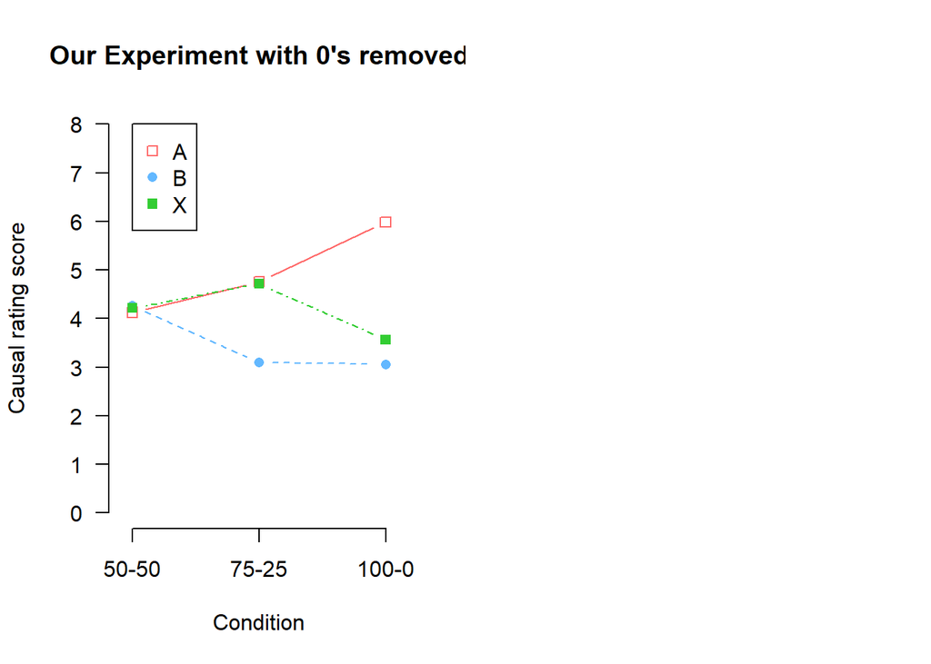

```r
emptyPlot(c(-5,105),c(0,8), xaxt = "none", ymark=c(0,1,2,3,4,5,6,7,8), bty='n', main = "Our Experiment with 0's removed", xlab = "Condition", ylab = "Causal rating score")
A <- c(b1$A)
B <- c(b1$B)
X <- c(b1$X)
points(c(0, 50, 100),A, pch = 0, type = "b", col = "indianred1")
points(c(0, 50, 100),B, pch =16, type = "b", lty = 2, col = "steelblue1")
points(c(0, 50, 100),X, pch =15, type = "b", lty = 4, col = "limegreen")
legend(0.05,8,legend =c("A", "B", "X"), pch = c(0,16,15), col = c("indianred1", "steelblue1", "limegreen"))
axis(1, at = c(0,50,100), labels = c("50-50", "75-25", "100-0"))
```

### Averages Thicker lines

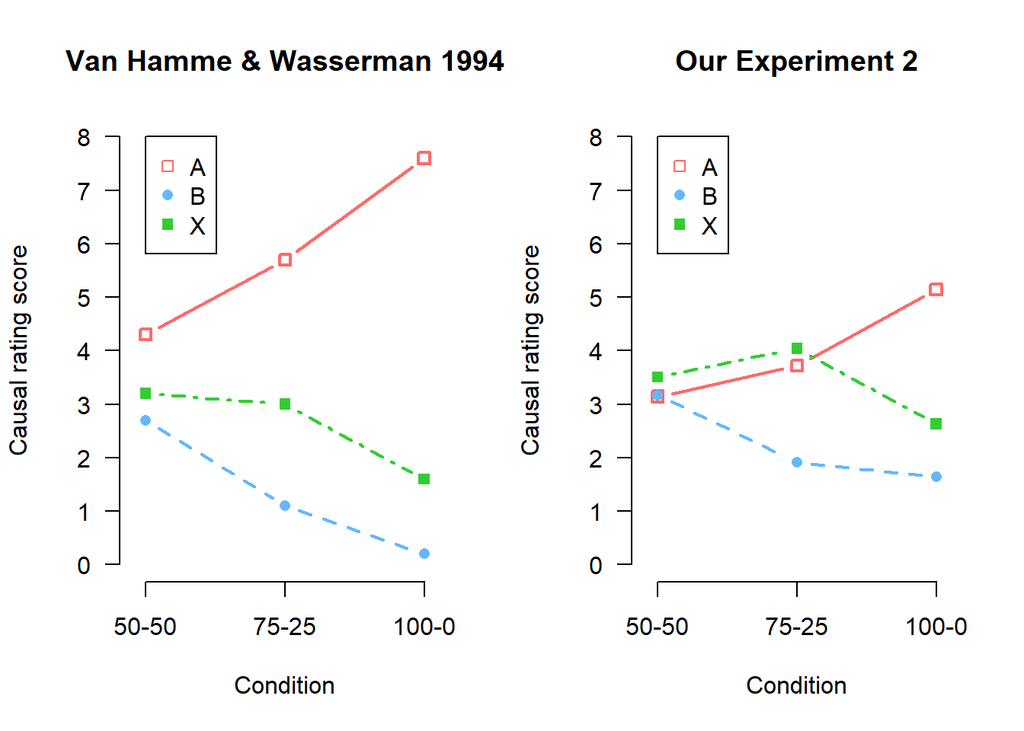

```r
par(mfrow = c(1,2))
par(las=1)
#original plot
emptyPlot(c(-5,105),c(0,8), xaxt = "none", ymark=c(0,1,2,3,4,5,6,7,8), bty='n', main = "Van Hamme & Wasserman 1994", xlab = "Condition", ylab = "Causal rating score")
A <- c(4.3,5.7,7.6)
B <- c(2.7, 1.1, 0.2)
X <- c(3.2,3,1.6)
points(c(0, 50, 100),A, pch = 0, type = "b", col = "indianred1", lwd = 2)
points(c(0, 50, 100),B, pch =16, type = "b", lty = 2, col = "steelblue1", lwd = 2)
points(c(0, 50, 100),X, pch =15, type = "b", lty = 4, col = "limegreen", lwd =2)
legend(0.05,8,legend =c("A", "B", "X"), pch = c(0,16,15), col = c("indianred1", "steelblue1", "limegreen"))
axis(1, at = c(0,50,100), labels = c("50-50", "75-25", "100-0"))

emptyPlot(c(-5,105),c(0,8), xaxt = "none", ymark=c(0,1,2,3,4,5,6,7,8), bty='n', main = "Our Experiment 2", xlab = "Condition", ylab = "Causal rating score")
A <- c(a1$A)
B <- c(a1$B)
X <- c(a1$X)
points(c(0, 50, 100),A, pch = 0, type = "b", col = "indianred1", lwd = 2)
points(c(0, 50, 100),B, pch =16, type = "b", lty = 2, col = "steelblue1", lwd = 2)
points(c(0, 50, 100),X, pch =15, type = "b", lty = 4, col = "limegreen", lwd = 2)
legend(0.05,8,legend =c("A", "B", "X"), pch = c(0,16,15), col = c("indianred1", "steelblue1", "limegreen"))
axis(1, at = c(0,50,100), labels = c("50-50", "75-25", "100-0"))
```

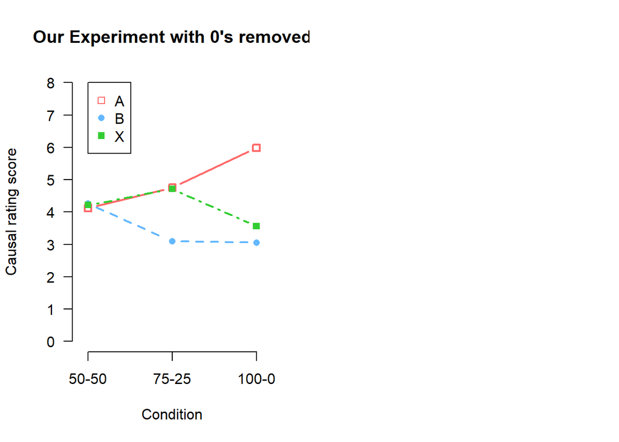

```r
emptyPlot(c(-5,105),c(0,8), xaxt = "none", ymark=c(0,1,2,3,4,5,6,7,8), bty='n', main = "Our Experiment with 0's removed", xlab = "Condition", ylab = "Causal rating score")
A <- c(b1$A)
B <- c(b1$B)
X <- c(b1$X)
points(c(0, 50, 100),A, pch = 0, type = "b", col = "indianred1", lwd = 2)
points(c(0, 50, 100),B, pch =16, type = "b", lty = 2, col = "steelblue1", lwd = 2)
points(c(0, 50, 100),X, pch =15, type = "b", lty = 4, col = "limegreen", lwd = 2)
legend(0.05,8,legend =c("A", "B", "X"), pch = c(0,16,15), col = c("indianred1", "steelblue1", "limegreen"))
axis(1, at = c(0,50,100), labels = c("50-50", "75-25", "100-0"))
```

### Averages SE

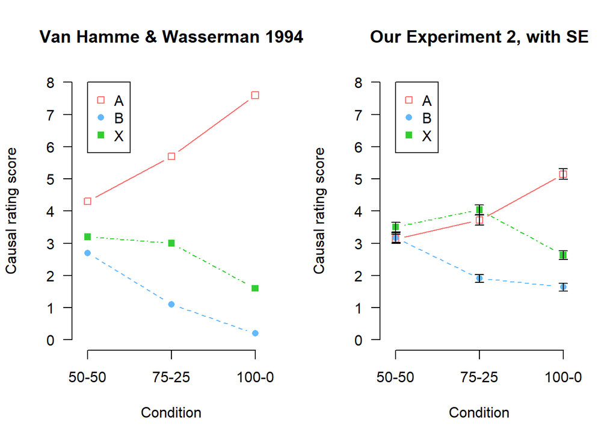

```r
par(mfrow = c(1,2))
par(las=1)
#original plot
emptyPlot(c(-5,105),c(0,8), xaxt = "none", ymark=c(0,1,2,3,4,5,6,7,8), bty='n', main = "Van Hamme & Wasserman 1994", xlab = "Condition", ylab = "Causal rating score")
A <- c(4.3,5.7,7.6)
B <- c(2.7, 1.1, 0.2)
X <- c(3.2,3,1.6)
points(c(0, 50, 100),A, pch = 0, type = "b", col = "indianred1")
points(c(0, 50, 100),B, pch =16, type = "b", lty = 2, col = "steelblue1")
points(c(0, 50, 100),X, pch =15, type = "b", lty = 4, col = "limegreen")
legend(0.05,8,legend =c("A", "B", "X"), pch = c(0,16,15), col = c("indianred1", "steelblue1", "limegreen"))
axis(1, at = c(0,50,100), labels = c("50-50", "75-25", "100-0"))

emptyPlot(c(-5,105),c(0,8), xaxt = "none", ymark=c(0,1,2,3,4,5,6,7,8), bty='n', main = "Our Experiment 2, with SE", xlab = "Condition", ylab = "Causal rating score")
A <- c(a1$A)
B <- c(a1$B)
X <- c(a1$X)
points(c(0, 50, 100),A, pch = 0, type = "b", col = "indianred1")
points(c(0, 50, 100),B, pch =16, type = "b", lty = 2, col = "steelblue1")
points(c(0, 50, 100),X, pch =15, type = "b", lty = 4, col = "limegreen")
legend(0.05,8,legend =c("A", "B", "X"), pch = c(0,16,15), col = c("indianred1", "steelblue1", "limegreen"))
errorbars(x= c(0,50,100), y = a1$A, top = SECondA, bottom = SECondA, add = TRUE, length = 0.05)
errorbars(x= c(0,50,100), y = a1$B, top = SECondB, bottom = SECondB, add = TRUE, length = 0.05)
errorbars(x= c(0,50,100), y = a1$X, top = SECondX, bottom = SECondX, add = TRUE, length = 0.05)
axis(1, at = c(0,50,100), labels = c("50-50", "75-25", "100-0"))
```

### Cond 000

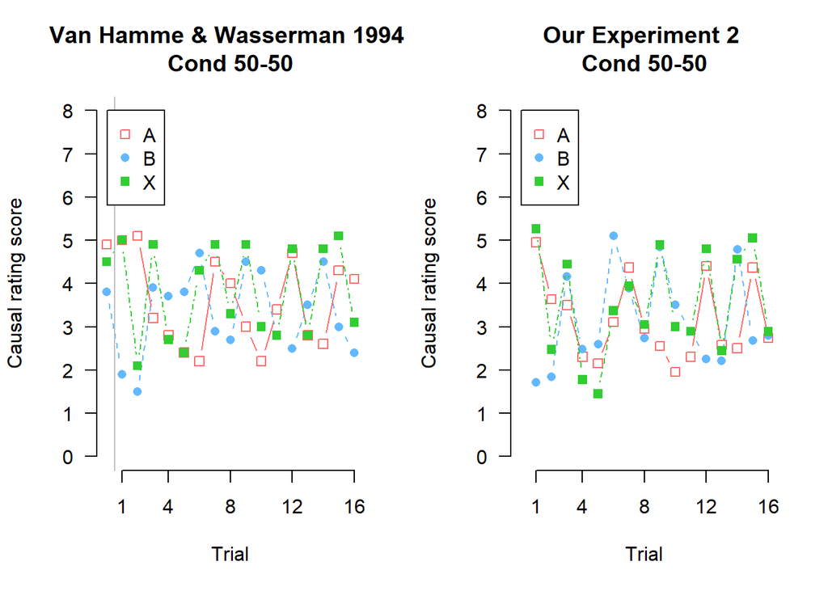

```r
par(mfrow = c(1,2))
par(las=1)
#original plot
emptyPlot(c(0,16),c(0,8), xmark = c(1,4,8,12,16), ymark=c(0,1,2,3,4,5,6,7,8), bty='n', main = "Van Hamme & Wasserman 1994 \nCond 50-50", xlab = "Trial", ylab = "Causal rating score")
A <- c(4.9, 5, 5.1, 3.2, 2.8, 2.4, 2.2, 4.5, 4, 3, 2.2, 3.4, 4.7, 2.8, 2.6, 4.3, 4.1)
B <- c(3.8, 1.9, 1.5, 3.9, 3.7, 3.8, 4.7, 2.9, 2.7, 4.5, 4.3, 2.8, 2.5, 3.5, 4.5, 3, 2.4)
X <- c(4.5, 5, 2.1, 4.9, 2.7, 2.4, 4.3, 4.9, 3.3, 4.9, 3, 2.8, 4.8,2.8, 4.8, 5.1, 3.1)
points(c(0:16),A, pch = 0, type = "b", col = "indianred1")
points(c(0:16),B, pch =16, type = "b", lty = 2, col = "steelblue1")
points(c(0:16),X, pch =15, type = "b", lty = 4, col = "limegreen")
abline(v=0.5, col="grey", lty = 1)
legend(0.05,8,legend =c("A", "B", "X"), pch = c(0,16,15), col = c("indianred1", "steelblue1", "limegreen"))

emptyPlot(c(0,16),c(0,8), xmark = c(1,4,8,12,16), ymark=c(0,1,2,3,4,5,6,7,8), bty='n', main = "Our Experiment 2 \nCond 50-50", xlab = "Trial", ylab = "Causal rating score")
A <- Cond000$A
B <- Cond000$B
X <- Cond000$X
points(c(1:16),A, pch = 0, type = "b", col = "indianred1")
points(c(1:16),B, pch =16, type = "b", lty = 2, col = "steelblue1")
points(c(1:16),X, pch =15, type = "b", lty = 4, col = "limegreen")
legend(0.05,8,legend =c("A", "B", "X"), pch = c(0,16,15), col = c("indianred1", "steelblue1", "limegreen"))
```

### Cond 000 Thicker lines

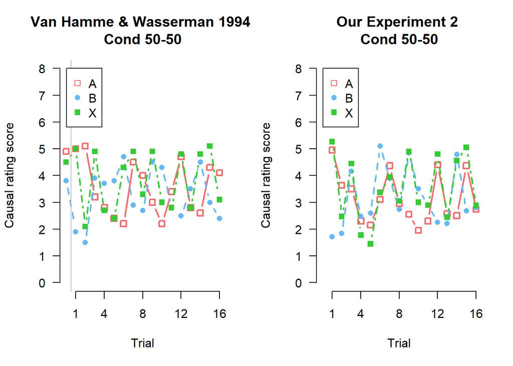

```r
par(mfrow = c(1,2))
par(las=1)
#original plot
emptyPlot(c(0,16),c(0,8), xmark = c(1,4,8,12,16), ymark=c(0,1,2,3,4,5,6,7,8), bty='n', main = "Van Hamme & Wasserman 1994 \nCond 50-50", xlab = "Trial", ylab = "Causal rating score")
A <- c(4.9, 5, 5.1, 3.2, 2.8, 2.4, 2.2, 4.5, 4, 3, 2.2, 3.4, 4.7, 2.8, 2.6, 4.3, 4.1)
B <- c(3.8, 1.9, 1.5, 3.9, 3.7, 3.8, 4.7, 2.9, 2.7, 4.5, 4.3, 2.8, 2.5, 3.5, 4.5, 3, 2.4)
X <- c(4.5, 5, 2.1, 4.9, 2.7, 2.4, 4.3, 4.9, 3.3, 4.9, 3, 2.8, 4.8,2.8, 4.8, 5.1, 3.1)
points(c(0:16),A, pch = 0, type = "b", col = "indianred1", lwd = 2)
points(c(0:16),B, pch =16, type = "b", lty = 2, col = "steelblue1", lwd = 2)
points(c(0:16),X, pch =15, type = "b", lty = 4, col = "limegreen", lwd = 2)
abline(v=0.5, col="grey", lty = 1)
legend(0.05,8,legend =c("A", "B", "X"), pch = c(0,16,15), col = c("indianred1", "steelblue1", "limegreen"))

emptyPlot(c(0,16),c(0,8), xmark = c(1,4,8,12,16), ymark=c(0,1,2,3,4,5,6,7,8), bty='n', main = "Our Experiment 2 \nCond 50-50", xlab = "Trial", ylab = "Causal rating score")
A <- Cond000$A
B <- Cond000$B
X <- Cond000$X
points(c(1:16),A, pch = 0, type = "b", col = "indianred1", lwd =2)
points(c(1:16),B, pch =16, type = "b", lty = 2, col = "steelblue1", lwd = 2)
points(c(1:16),X, pch =15, type = "b", lty = 4, col = "limegreen", lwd =2)
legend(0.05,8,legend =c("A", "B", "X"), pch = c(0,16,15), col = c("indianred1", "steelblue1", "limegreen"))
```

### Cond 000 SE

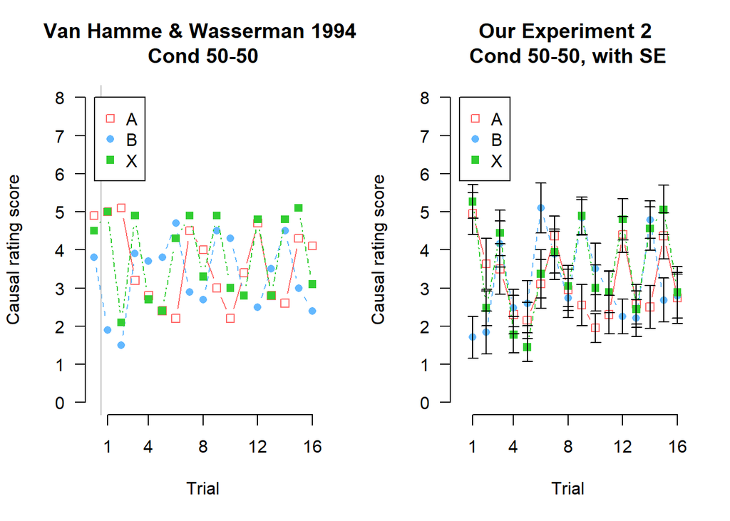

```r
par(mfrow = c(1,2))
par(las=1)
#original plot
emptyPlot(c(0,16),c(0,8), xmark = c(1,4,8,12,16), ymark=c(0,1,2,3,4,5,6,7,8), bty='n', main = "Van Hamme & Wasserman 1994 \nCond 50-50", xlab = "Trial", ylab = "Causal rating score")
A <- c(4.9, 5, 5.1, 3.2, 2.8, 2.4, 2.2, 4.5, 4, 3, 2.2, 3.4, 4.7, 2.8, 2.6, 4.3, 4.1)
B <- c(3.8, 1.9, 1.5, 3.9, 3.7, 3.8, 4.7, 2.9, 2.7, 4.5, 4.3, 2.8, 2.5, 3.5, 4.5, 3, 2.4)
X <- c(4.5, 5, 2.1, 4.9, 2.7, 2.4, 4.3, 4.9, 3.3, 4.9, 3, 2.8, 4.8,2.8, 4.8, 5.1, 3.1)
points(c(0:16),A, pch = 0, type = "b", col = "indianred1")
points(c(0:16),B, pch =16, type = "b", lty = 2, col = "steelblue1")
points(c(0:16),X, pch =15, type = "b", lty = 4, col = "limegreen")
abline(v=0.5, col="grey", lty = 1)
legend(0.05,8,legend =c("A", "B", "X"), pch = c(0,16,15), col = c("indianred1", "steelblue1", "limegreen"))

emptyPlot(c(0,16),c(0,8), xmark = c(1,4,8,12,16), ymark=c(0,1,2,3,4,5,6,7,8), bty='n', main = "Our Experiment 2 \nCond 50-50, with SE", xlab = "Trial", ylab = "Causal rating score")
A <- Cond000$A
B <- Cond000$B
X <- Cond000$X
points(c(1:16),A, pch = 0, type = "b", col = "indianred1")
points(c(1:16),B, pch =16, type = "b", lty = 2, col = "steelblue1")
points(c(1:16),X, pch =15, type = "b", lty = 4, col = "limegreen")
errorbars(x= c(1:16), y = Cond000$A, top = SETrials000A, bottom = SETrials000A, add = TRUE, length = 0.05)
errorbars(x= c(1:16), y = Cond000$B, top = SETrials000B, bottom = SETrials000B, add = TRUE, length = 0.05)
errorbars(x= c(1:16), y = Cond000$X, top = SETrials000X, bottom = SETrials000X, add = TRUE, length = 0.05)
legend(0.05,8,legend =c("A", "B", "X"), pch = c(0,16,15), col = c("indianred1", "steelblue1", "limegreen"))
```

### Cond 050

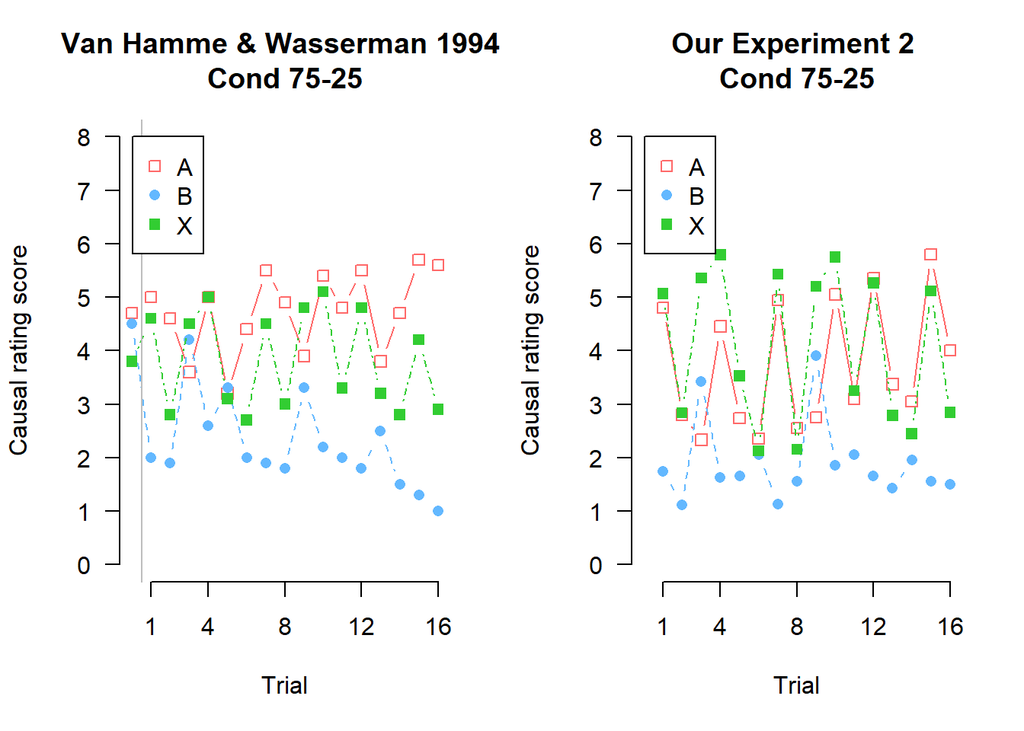

```r
par(mfrow = c(1,2))
par(las=1)
#original plot
emptyPlot(c(0,16),c(0,8), xmark = c(1,4,8,12,16), ymark=c(0,1,2,3,4,5,6,7,8), bty='n', main = "Van Hamme & Wasserman 1994 \nCond 75-25", xlab = "Trial", ylab = "Causal rating score")
A <- c(4.7,5,4.6,3.6,5,3.2,4.4,5.5,4.9,3.9,5.4,4.8,5.5,3.8,4.7,5.7,5.6)
B <- c(4.5,2,1.9,4.2,2.6,3.3,2,1.9,1.8,3.3,2.2,2,1.8,2.5,1.5,1.3,1)
X <- c(3.8,4.6,2.8,4.5,5,3.1,2.7,4.5,3,4.8,5.1,3.3,4.8,3.2,2.8,4.2,2.9)
points(c(0:16),A, pch = 0, type = "b", col = "indianred1")
points(c(0:16),B, pch =16, type = "b", lty = 2, col = "steelblue1")
points(c(0:16),X, pch =15, type = "b", lty = 4, col = "limegreen")
abline(v=0.5, col="grey", lty = 1)
legend(0.05,8,legend =c("A", "B", "X"), pch = c(0,16,15), col = c("indianred1", "steelblue1", "limegreen"))

emptyPlot(c(0,16),c(0,8), xmark = c(1,4,8,12,16), ymark=c(0,1,2,3,4,5,6,7,8), bty='n', main = "Our Experiment 2 \nCond 75-25", xlab = "Trial", ylab = "Causal rating score")
A <- Cond050$A
B <- Cond050$B
X <- Cond050$X
points(c(1:16),A, pch = 0, type = "b", col = "indianred1")
points(c(1:16),B, pch =16, type = "b", lty = 2, col = "steelblue1")
points(c(1:16),X, pch =15, type = "b", lty = 4, col = "limegreen")
legend(0.05,8,legend =c("A", "B", "X"), pch = c(0,16,15), col = c("indianred1", "steelblue1", "limegreen"))
```

### Cond 050 Thicker lines

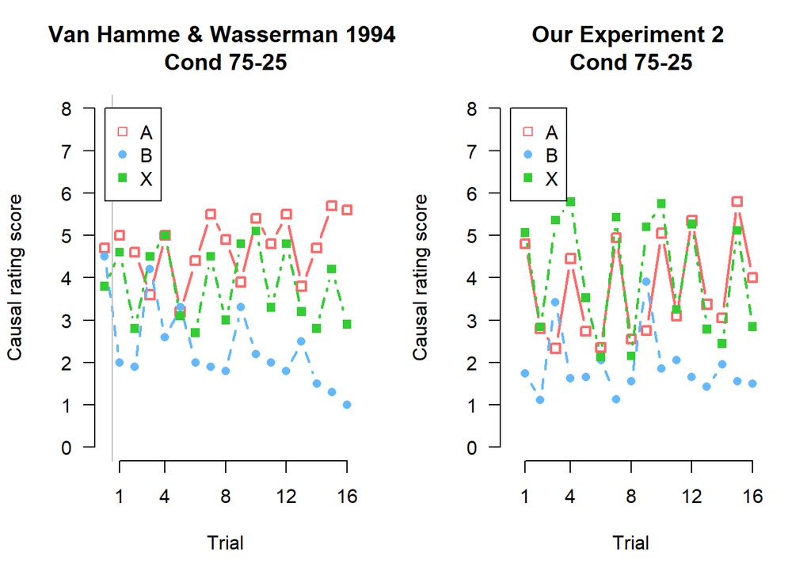

```r
par(mfrow = c(1,2))
par(las=1)
#original plot
emptyPlot(c(0,16),c(0,8), xmark = c(1,4,8,12,16), ymark=c(0,1,2,3,4,5,6,7,8), bty='n', main = "Van Hamme & Wasserman 1994 \nCond 75-25", xlab = "Trial", ylab = "Causal rating score")
A <- c(4.7,5,4.6,3.6,5,3.2,4.4,5.5,4.9,3.9,5.4,4.8,5.5,3.8,4.7,5.7,5.6)
B <- c(4.5,2,1.9,4.2,2.6,3.3,2,1.9,1.8,3.3,2.2,2,1.8,2.5,1.5,1.3,1)
X <- c(3.8,4.6,2.8,4.5,5,3.1,2.7,4.5,3,4.8,5.1,3.3,4.8,3.2,2.8,4.2,2.9)
points(c(0:16),A, pch = 0, type = "b", col = "indianred1", lwd = 2)
points(c(0:16),B, pch =16, type = "b", lty = 2, col = "steelblue1", lwd = 2)
points(c(0:16),X, pch =15, type = "b", lty = 4, col = "limegreen", lwd = 2)
abline(v=0.5, col="grey", lty = 1)
legend(0.05,8,legend =c("A", "B", "X"), pch = c(0,16,15), col = c("indianred1", "steelblue1", "limegreen"))

emptyPlot(c(0,16),c(0,8), xmark = c(1,4,8,12,16), ymark=c(0,1,2,3,4,5,6,7,8), bty='n', main = "Our Experiment 2 \nCond 75-25", xlab = "Trial", ylab = "Causal rating score")
A <- Cond050$A
B <- Cond050$B
X <- Cond050$X
points(c(1:16),A, pch = 0, type = "b", col = "indianred1", lwd = 2)
points(c(1:16),B, pch =16, type = "b", lty = 2, col = "steelblue1", lwd = 2)
points(c(1:16),X, pch =15, type = "b", lty = 4, col = "limegreen", lwd = 2)
legend(0.05,8,legend =c("A", "B", "X"), pch = c(0,16,15), col = c("indianred1", "steelblue1", "limegreen"))
```

### Cond 050 SE

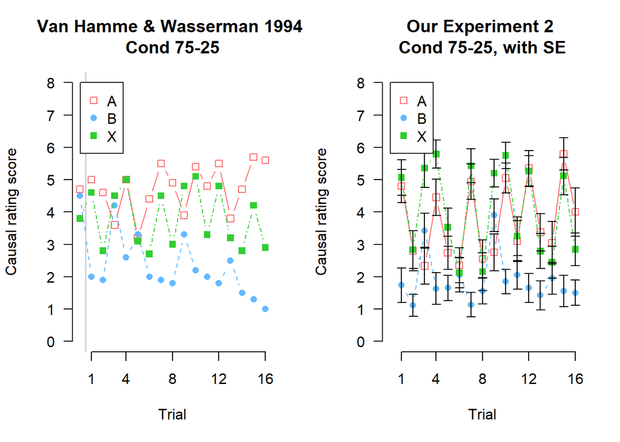

```r
par(mfrow = c(1,2))
par(las=1)
#original plot
emptyPlot(c(0,16),c(0,8), xmark = c(1,4,8,12,16), ymark=c(0,1,2,3,4,5,6,7,8), bty='n', main = "Van Hamme & Wasserman 1994 \nCond 75-25", xlab = "Trial", ylab = "Causal rating score")
A <- c(4.7,5,4.6,3.6,5,3.2,4.4,5.5,4.9,3.9,5.4,4.8,5.5,3.8,4.7,5.7,5.6)
B <- c(4.5,2,1.9,4.2,2.6,3.3,2,1.9,1.8,3.3,2.2,2,1.8,2.5,1.5,1.3,1)
X <- c(3.8,4.6,2.8,4.5,5,3.1,2.7,4.5,3,4.8,5.1,3.3,4.8,3.2,2.8,4.2,2.9)
points(c(0:16),A, pch = 0, type = "b", col = "indianred1")
points(c(0:16),B, pch =16, type = "b", lty = 2, col = "steelblue1")
points(c(0:16),X, pch =15, type = "b", lty = 4, col = "limegreen")
abline(v=0.5, col="grey", lty = 1)
legend(0.05,8,legend =c("A", "B", "X"), pch = c(0,16,15), col = c("indianred1", "steelblue1", "limegreen"))

emptyPlot(c(0,16),c(0,8), xmark = c(1,4,8,12,16), ymark=c(0,1,2,3,4,5,6,7,8), bty='n', main = "Our Experiment 2 \nCond 75-25, with SE", xlab = "Trial", ylab = "Causal rating score")
A <- Cond050$A
B <- Cond050$B
X <- Cond050$X
points(c(1:16),A, pch = 0, type = "b", col = "indianred1")
points(c(1:16),B, pch =16, type = "b", lty = 2, col = "steelblue1")
points(c(1:16),X, pch =15, type = "b", lty = 4, col = "limegreen")
errorbars(x= c(1:16), y = Cond050$A, top = SETrials050A, bottom = SETrials050A, add = TRUE, length = 0.05)
errorbars(x= c(1:16), y = Cond050$B, top = SETrials050B, bottom = SETrials050B, add = TRUE, length = 0.05)
errorbars(x= c(1:16), y = Cond050$X, top = SETrials050X, bottom = SETrials050X, add = TRUE, length = 0.05)
legend(0.05,8,legend =c("A", "B", "X"), pch = c(0,16,15), col = c("indianred1", "steelblue1", "limegreen"))
```

### Cond 100

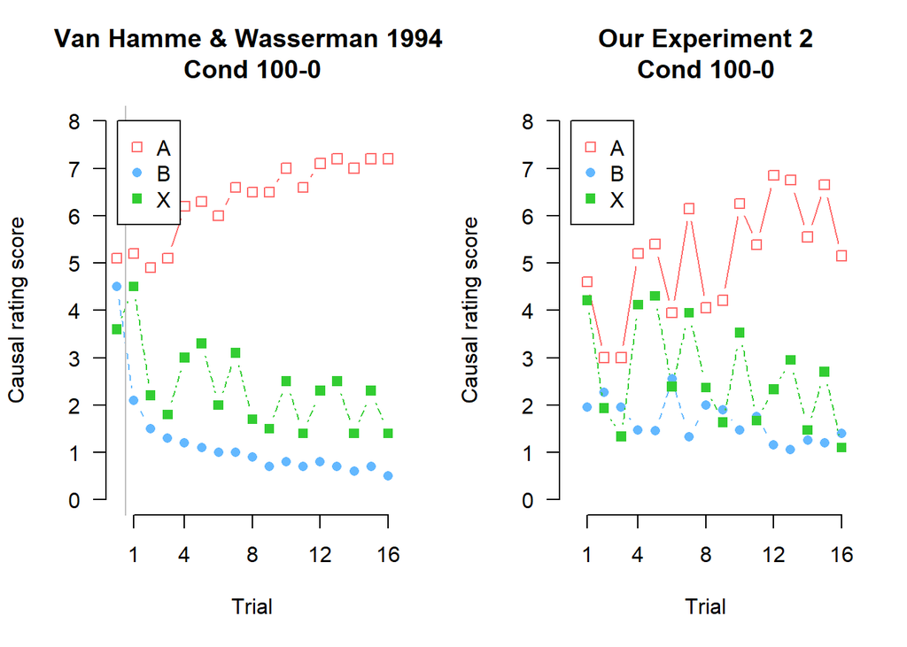

```r
par(mfrow = c(1,2))
par(las=1)
#original plot
emptyPlot(c(0,16),c(0,8), xmark = c(1,4,8,12,16), ymark=c(0,1,2,3,4,5,6,7,8), bty='n', main = "Van Hamme & Wasserman 1994 \nCond 100-0", xlab = "Trial", ylab = "Causal rating score")
A <- c(5.1,5.2,4.9,5.1,6.2,6.3,6,6.6,6.5,6.5,7,6.6,7.1,7.2,7,7.2,7.2)
B <- c(4.5,2.1,1.5,1.3,1.2,1.1,1,1,0.9,0.7,0.8,0.7,0.8,0.7,0.6,0.7,0.5)
X <- c(3.6,4.5,2.2,1.8,3,3.3,2,3.1,1.7,1.5,2.5,1.4,2.3,2.5,1.4,2.3,1.4)
points(c(0:16),A, pch = 0, type = "b", col = "indianred1")
points(c(0:16),B, pch =16, type = "b", lty = 2, col = "steelblue1")
points(c(0:16),X, pch =15, type = "b", lty = 4, col = "limegreen")
abline(v=0.5, col="grey", lty = 1)
legend(0.05,8,legend =c("A", "B", "X"), pch = c(0,16,15), col = c("indianred1", "steelblue1", "limegreen"))

emptyPlot(c(0,16),c(0,8), xmark = c(1,4,8,12,16), ymark=c(0,1,2,3,4,5,6,7,8), bty='n', main = "Our Experiment 2\nCond 100-0", xlab = "Trial", ylab = "Causal rating score")
A <- Cond100$A
B <- Cond100$B
X <- Cond100$X
points(c(1:16),A, pch = 0, type = "b", col = "indianred1")
points(c(1:16),B, pch =16, type = "b", lty = 2, col = "steelblue1")
points(c(1:16),X, pch =15, type = "b", lty = 4, col = "limegreen")
legend(0.05,8,legend =c("A", "B", "X"), pch = c(0,16,15), col = c("indianred1", "steelblue1", "limegreen"))
```

### Cond 100 Thicker Lines

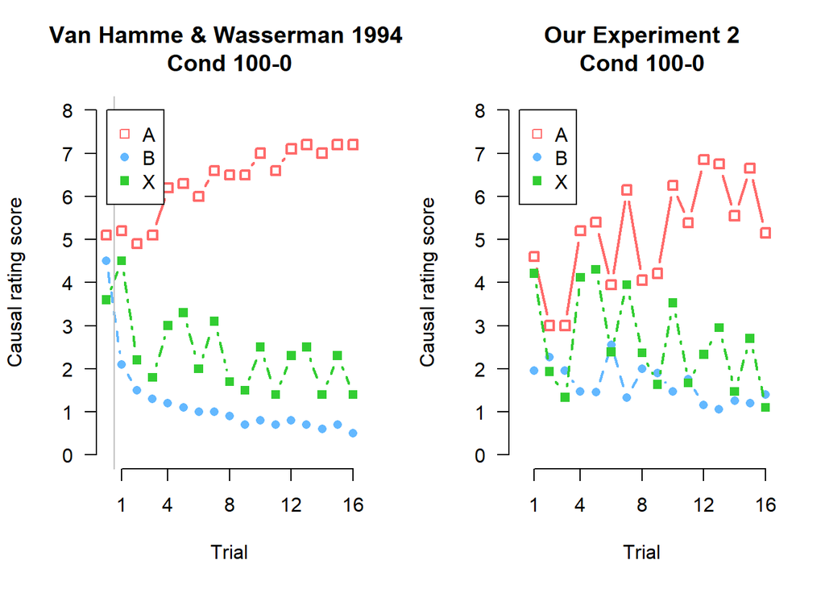

```r
par(mfrow = c(1,2))
par(las=1)
#original plot
emptyPlot(c(0,16),c(0,8), xmark = c(1,4,8,12,16), ymark=c(0,1,2,3,4,5,6,7,8), bty='n', main = "Van Hamme & Wasserman 1994 \nCond 100-0", xlab = "Trial", ylab = "Causal rating score")
A <- c(5.1,5.2,4.9,5.1,6.2,6.3,6,6.6,6.5,6.5,7,6.6,7.1,7.2,7,7.2,7.2)
B <- c(4.5,2.1,1.5,1.3,1.2,1.1,1,1,0.9,0.7,0.8,0.7,0.8,0.7,0.6,0.7,0.5)
X <- c(3.6,4.5,2.2,1.8,3,3.3,2,3.1,1.7,1.5,2.5,1.4,2.3,2.5,1.4,2.3,1.4)
points(c(0:16),A, pch = 0, type = "b", col = "indianred1", lwd = 2)
points(c(0:16),B, pch =16, type = "b", lty = 2, col = "steelblue1", lwd = 2)
points(c(0:16),X, pch =15, type = "b", lty = 4, col = "limegreen", lwd = 2)
abline(v=0.5, col="grey", lty = 1)
legend(0.05,8,legend =c("A", "B", "X"), pch = c(0,16,15), col = c("indianred1", "steelblue1", "limegreen"))

emptyPlot(c(0,16),c(0,8), xmark = c(1,4,8,12,16), ymark=c(0,1,2,3,4,5,6,7,8), bty='n', main = "Our Experiment 2\nCond 100-0", xlab = "Trial", ylab = "Causal rating score")
A <- Cond100$A
B <- Cond100$B
X <- Cond100$X
points(c(1:16),A, pch = 0, type = "b", col = "indianred1", lwd = 2)
points(c(1:16),B, pch =16, type = "b", lty = 2, col = "steelblue1", lwd = 2)
points(c(1:16),X, pch =15, type = "b", lty = 4, col = "limegreen", lwd = 2)
legend(0.05,8,legend =c("A", "B", "X"), pch = c(0,16,15), col = c("indianred1", "steelblue1", "limegreen"))
```

### Cond 100 SE

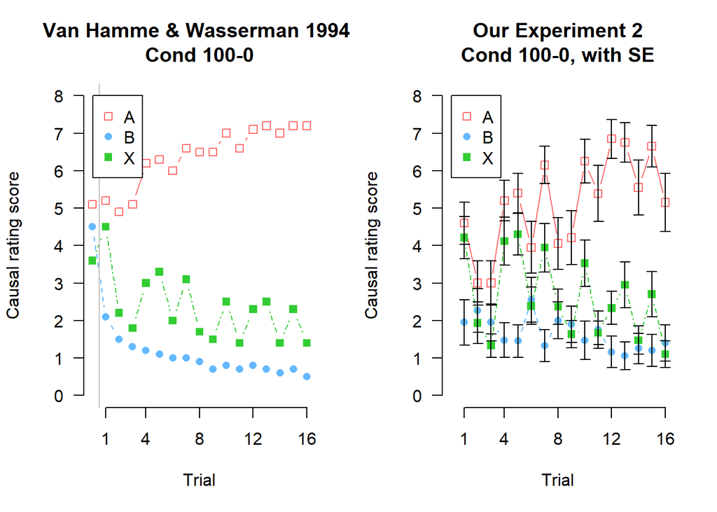

```r
par(mfrow = c(1,2))
par(las=1)
#original plot
emptyPlot(c(0,16),c(0,8), xmark = c(1,4,8,12,16), ymark=c(0,1,2,3,4,5,6,7,8), bty='n', main = "Van Hamme & Wasserman 1994 \nCond 100-0", xlab = "Trial", ylab = "Causal rating score")
A <- c(5.1,5.2,4.9,5.1,6.2,6.3,6,6.6,6.5,6.5,7,6.6,7.1,7.2,7,7.2,7.2)
B <- c(4.5,2.1,1.5,1.3,1.2,1.1,1,1,0.9,0.7,0.8,0.7,0.8,0.7,0.6,0.7,0.5)
X <- c(3.6,4.5,2.2,1.8,3,3.3,2,3.1,1.7,1.5,2.5,1.4,2.3,2.5,1.4,2.3,1.4)
points(c(0:16),A, pch = 0, type = "b", col = "indianred1")
points(c(0:16),B, pch =16, type = "b", lty = 2, col = "steelblue1")
points(c(0:16),X, pch =15, type = "b", lty = 4, col = "limegreen")
abline(v=0.5, col="grey", lty = 1)
legend(0.05,8,legend =c("A", "B", "X"), pch = c(0,16,15), col = c("indianred1", "steelblue1", "limegreen"))

emptyPlot(c(0,16),c(0,8), xmark = c(1,4,8,12,16), ymark=c(0,1,2,3,4,5,6,7,8), bty='n', main = "Our Experiment 2\nCond 100-0, with SE", xlab = "Trial", ylab = "Causal rating score")
A <- Cond100$A
B <- Cond100$B
X <- Cond100$X
points(c(1:16),A, pch = 0, type = "b", col = "indianred1")
points(c(1:16),B, pch =16, type = "b", lty = 2, col = "steelblue1")
points(c(1:16),X, pch =15, type = "b", lty = 4, col = "limegreen")
errorbars(x= c(1:16), y = Cond100$A, top = SETrials100A, bottom = SETrials100A, add = TRUE, length = 0.05)
errorbars(x= c(1:16), y = Cond100$B, top = SETrials100B, bottom = SETrials100B, add = TRUE, length = 0.05)
errorbars(x= c(1:16), y = Cond100$X, top = SETrials100X, bottom = SETrials100X, add = TRUE, length = 0.05)
legend(0.05,8,legend =c("A", "B", "X"), pch = c(0,16,15), col = c("indianred1", "steelblue1", "limegreen"))
```

```r
#randomly pick 5 participants (and keep those same participants, so the random is only for picking them the first time)
#sample(unique(dat$prolific_id), 5, replace = TRUE)
#gives us:
#602e3452f1c6b793faa7bcdd 5fc3f24cdb80f92ddc47afa1 5dfe08627f08edaa7de5963f 605bd0169853b502f34b51c3 6087b7e0f1f00cdd351f12ad

#so I'll plot those five people
P1 <- subset(train, train$prolific_id == "602e3452f1c6b793faa7bcdd")
P2 <- subset(train, train$prolific_id == "5fc3f24cdb80f92ddc47afa1")
P3 <- subset(train, train$prolific_id == "6087b7e0f1f00cdd351f12ad")
P4 <- subset(train, train$prolific_id == "605bd0169853b502f34b51c3")
P5 <- subset(train, train$prolific_id == "5dfe08627f08edaa7de5963f")

P1<-subset(P1, P1$Cond != "Pre1" & P1$Cond != "Pre2" & P1$Cond != "Pre3")
P2<-subset(P2, P2$Cond != "Pre1" & P2$Cond != "Pre2" & P2$Cond != "Pre3")
P3<-subset(P3, P3$Cond != "Pre1" & P3$Cond != "Pre2" & P3$Cond != "Pre3")
P4<-subset(P4, P4$Cond != "Pre1" & P4$Cond != "Pre2" & P4$Cond != "Pre3")
P5<-subset(P5, P5$Cond != "Pre1" & P5$Cond != "Pre2" & P5$Cond != "Pre3")
```

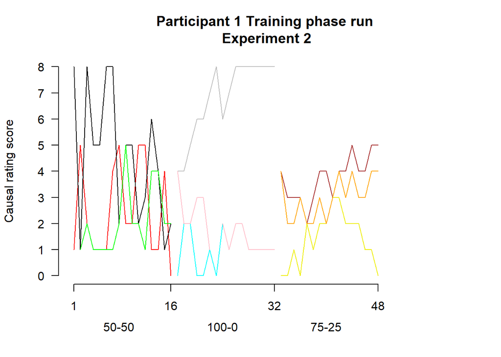

```r
#p1 had Cond 0, 100, 50
par(mfrow = c(1,1))
par(las = 1)
emptyPlot(c(1,60), c(0,8), xmark = c(1,16,32,48), ymark= c(0,1,2,3,4,5,6,7,8), bty = 'n', main = "Participant 1 Training phase run\n Experiment 2", xlab = "", ylab = "Causal rating score")
points(c(1:16), P1$responseR1[P1$blockNr == "Block1"], type = 'l', col = "red", lty = 1, lwd = 1)
points(c(1:16), P1$responseR2[P1$blockNr == "Block1"], type = 'l', col = "black", lty = 1, lwd = 1)
points(c(1:16), P1$responseR3[P1$blockNr == "Block1"], type = 'l', col = "green", lty = 1, lwd = 1)
points(c(17:32), P1$responseR1[P1$blockNr == "Block2"], type = 'l', col = "grey", lty = 1, lwd = 1)
points(c(17:32), P1$responseR2[P1$blockNr == "Block2"], type = 'l', col = "cyan", lty = 1, lwd = 1)
points(c(17:32), P1$responseR3[P1$blockNr == "Block2"], type = 'l', col = "pink", lty = 1, lwd = 1)
points(c(33:48), P1$responseR1[P1$blockNr == "Block3"], type = 'l', col = "brown", lty = 1, lwd = 1)
points(c(33:48), P1$responseR2[P1$blockNr == "Block3"], type = 'l', col = "yellow2", lty = 1, lwd = 1)
points(c(33:48), P1$responseR3[P1$blockNr == "Block3"], type = 'l', col = "orange", lty = 1, lwd = 1)
mtext("50-50", side = 1, at = 8, line = 2.5)
mtext("100-0", side = 1, at = 24, line = 2.5)
mtext("75-25", side = 1, at = 40, line = 2.5)
```

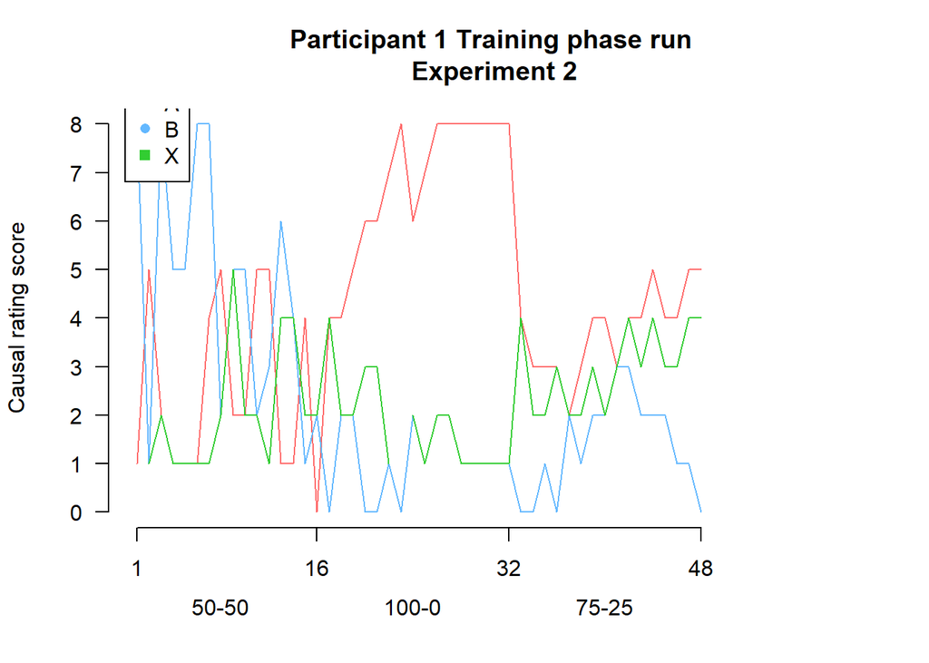

```r
#still P1
par(mfrow = c(1,1))
par(las = 1)
emptyPlot(c(1,60), c(0,8), xmark = c(1,16,32,48), ymark= c(0,1,2,3,4,5,6,7,8), bty = 'n', main = "Participant 1 Training phase run\n Experiment 2", xlab = "", ylab = "Causal rating score")
points(c(1:48), P1$responseR1, type = 'l', col = "indianred1", lty = 1, lwd = 1)
points(c(1:48), P1$responseR2, type = 'l', col = "steelblue1", lty = 1, lwd = 1)
points(c(1:48), P1$responseR3, type = 'l', col = "limegreen", lty = 1, lwd = 1)
mtext("50-50", side = 1, at = 8, line = 2.5)
mtext("100-0", side = 1, at = 24, line = 2.5)
mtext("75-25", side = 1, at = 40, line = 2.5)
legend(0.02,9,legend =c("A", "B", "X"), pch = c(0,16,15), col = c("indianred1", "steelblue1", "limegreen"))
```

wow! we really see what we would like to see here! For the 100-0 condition there is a clear difference between A and B, while in the 75-25 that also gradually becomes a thing, while in 50-50 they sort of converge

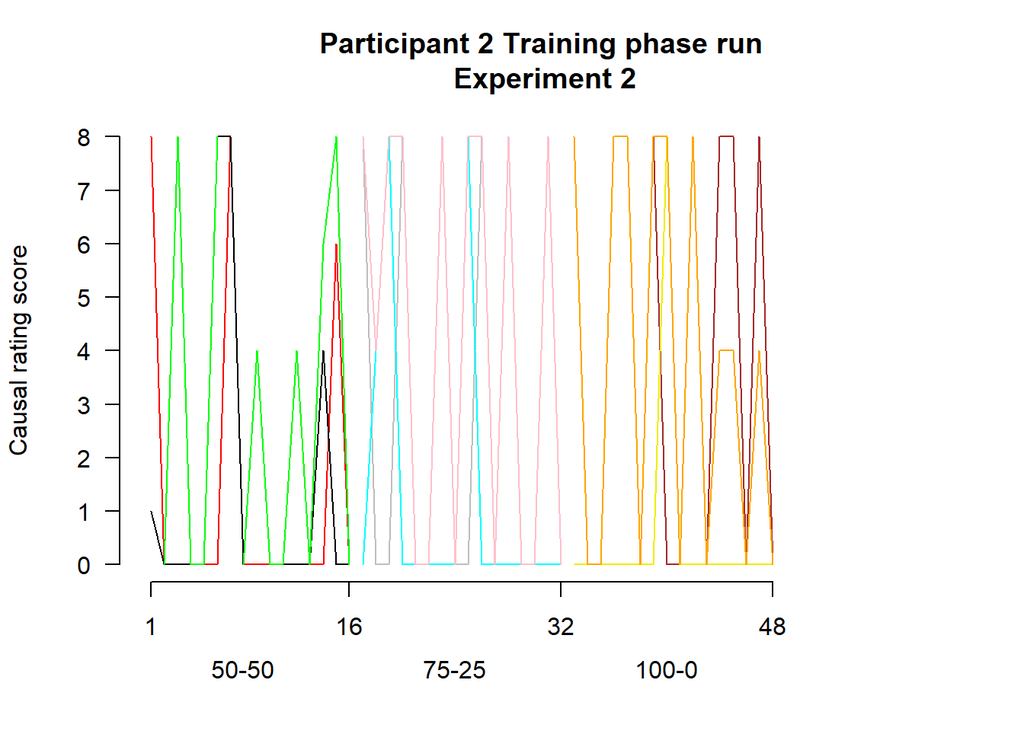

```r
#p2 had Cond 0, 50, 100.
par(mfrow = c(1,1))
par(las = 1)
emptyPlot(c(1,60), c(0,8), xmark = c(1,16,32,48), ymark= c(0,1,2,3,4,5,6,7,8), bty = 'n', main = "Participant 2 Training phase run\n Experiment 2", xlab = "", ylab = "Causal rating score")
points(c(1:16), P2$responseR1[P2$blockNr == "Block1"], type = 'l', col = "red", lty = 1, lwd = 1)
points(c(1:16), P2$responseR2[P2$blockNr == "Block1"], type = 'l', col = "black", lty = 1, lwd = 1)
points(c(1:16), P2$responseR3[P2$blockNr == "Block1"], type = 'l', col = "green", lty = 1, lwd = 1)
points(c(17:32), P2$responseR1[P2$blockNr == "Block2"], type = 'l', col = "grey", lty = 1, lwd = 1)
points(c(17:32), P2$responseR2[P2$blockNr == "Block2"], type = 'l', col = "cyan", lty = 1, lwd = 1)
points(c(17:32), P2$responseR3[P2$blockNr == "Block2"], type = 'l', col = "pink", lty = 1, lwd = 1)
points(c(33:48), P2$responseR1[P2$blockNr == "Block3"], type = 'l', col = "brown", lty = 1, lwd = 1)
points(c(33:48), P2$responseR2[P2$blockNr == "Block3"], type = 'l', col = "yellow2", lty = 1, lwd = 1)
points(c(33:48), P2$responseR3[P2$blockNr == "Block3"], type = 'l', col = "orange", lty = 1, lwd = 1)
mtext("50-50", side = 1, at = 8, line = 2.5)
mtext("75-25", side = 1, at = 24, line = 2.5)
mtext("100-0", side = 1, at = 40, line = 2.5)
```

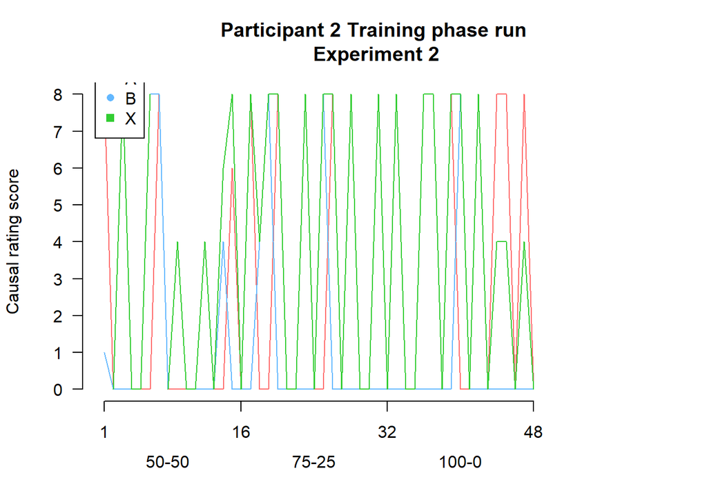

```r
#still P2
par(mfrow = c(1,1))
par(las = 1)
emptyPlot(c(1,60), c(0,8), xmark = c(1,16,32,48), ymark= c(0,1,2,3,4,5,6,7,8), bty = 'n', main = "Participant 2 Training phase run\n Experiment 2", xlab = "", ylab = "Causal rating score")
points(c(1:48), P2$responseR1, type = 'l', col = "indianred1", lty = 1, lwd = 1)
points(c(1:48), P2$responseR2, type = 'l', col = "steelblue1", lty = 1, lwd = 1)
points(c(1:48), P2$responseR3, type = 'l', col = "limegreen", lty = 1, lwd = 1)
mtext("50-50", side = 1, at = 8, line = 2.5)
mtext("75-25", side = 1, at = 24, line = 2.5)
mtext("100-0", side = 1, at = 40, line = 2.5)
legend(0.02,9,legend =c("A", "B", "X"), pch = c(0,16,15), col = c("indianred1", "steelblue1", "limegreen"))
```

This person seemed to know less what to do and just scored in the extremes, so either 0, 4 or 8

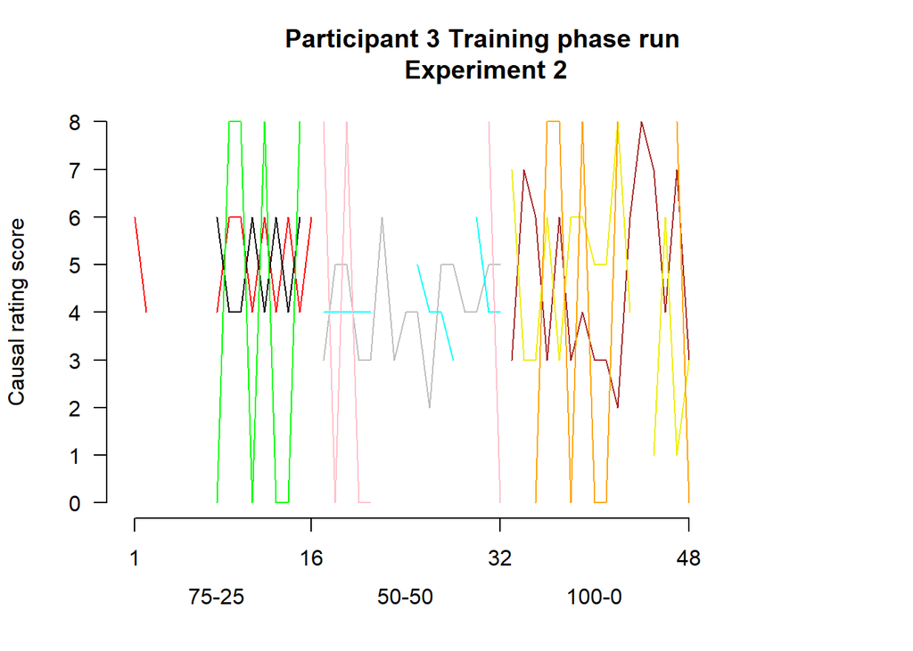

```r
#p3 had Cond 50, 0, 100.
par(mfrow = c(1,1))
par(las = 1)
emptyPlot(c(1,60), c(0,8), xmark = c(1,16,32,48), ymark= c(0,1,2,3,4,5,6,7,8), bty = 'n', main = "Participant 3 Training phase run\n Experiment 2", xlab = "", ylab = "Causal rating score")
points(c(1:16), P3$responseR1[P3$blockNr == "Block1"], type = 'l', col = "red", lty = 1, lwd = 1)
points(c(1:16), P3$responseR2[P3$blockNr == "Block1"], type = 'l', col = "black", lty = 1, lwd = 1)
points(c(1:16), P3$responseR3[P3$blockNr == "Block1"], type = 'l', col = "green", lty = 1, lwd = 1)
points(c(17:32), P3$responseR1[P3$blockNr == "Block2"], type = 'l', col = "grey", lty = 1, lwd = 1)
points(c(17:32), P3$responseR2[P3$blockNr == "Block2"], type = 'l', col = "cyan", lty = 1, lwd = 1)
points(c(17:32), P3$responseR3[P3$blockNr == "Block2"], type = 'l', col = "pink", lty = 1, lwd = 1)
points(c(33:48), P3$responseR1[P3$blockNr == "Block3"], type = 'l', col = "brown", lty = 1, lwd = 1)
points(c(33:48), P3$responseR2[P3$blockNr == "Block3"], type = 'l', col = "yellow2", lty = 1, lwd = 1)
points(c(33:48), P3$responseR3[P3$blockNr == "Block3"], type = 'l', col = "orange", lty = 1, lwd = 1)
mtext("75-25", side = 1, at = 8, line = 2.5)
mtext("50-50", side = 1, at = 24, line = 2.5)
mtext("100-0", side = 1, at = 40, line = 2.5)
```

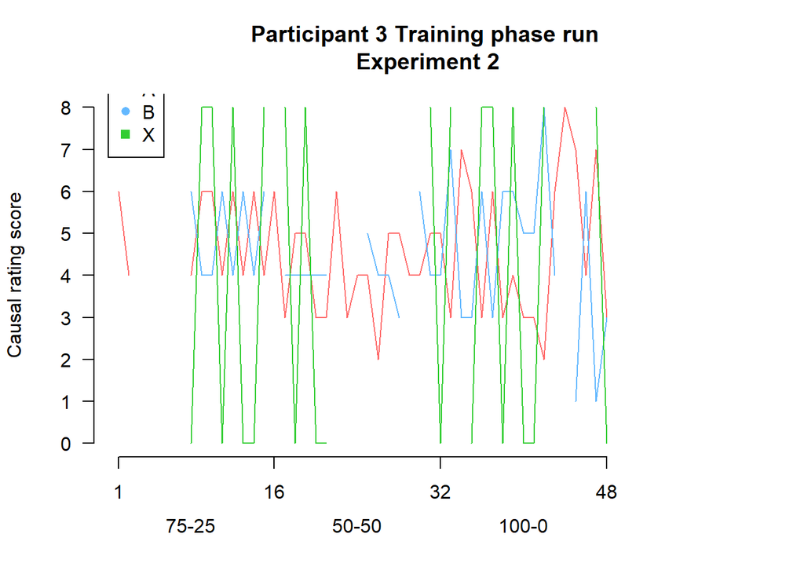

```r
#still P3
par(mfrow = c(1,1))
par(las = 1)
emptyPlot(c(1,60), c(0,8), xmark = c(1,16,32,48), ymark= c(0,1,2,3,4,5,6,7,8), bty = 'n', main = "Participant 3 Training phase run\n Experiment 2", xlab = "", ylab = "Causal rating score")
points(c(1:48), P3$responseR1, type = 'l', col = "indianred1", lty = 1, lwd = 1)
points(c(1:48), P3$responseR2, type = 'l', col = "steelblue1", lty = 1, lwd = 1)
points(c(1:48), P3$responseR3, type = 'l', col = "limegreen", lty = 1, lwd = 1)
mtext("75-25", side = 1, at = 8, line = 2.5)
mtext("50-50", side = 1, at = 24, line = 2.5)
mtext("100-0", side = 1, at = 40, line = 2.5)
legend(0.02,9,legend =c("A", "B", "X"), pch = c(0,16,15), col = c("indianred1", "steelblue1", "limegreen"))
```

This person had a lot of NA’s in their scoring, therefore their graph is a bit strange. As for what we can see, they seem to have scored X fairly extreme, while scoring A and B more moderate.

```r
#Calculating the average scores on the trials where "allergic reaction" was the outcome, and on trials where "No allergic reaction" was the outcome
#We would expect that the scores to the No allergic reaction would be lower on average
Allergic <- subset(train, train$Outcome == "Allergic reaction")
NotAllergic <- subset(train, train$Outcome == "No allergic reaction")

AllergicAvg <- aggregate(list(Allergic$responseR1, Allergic$responseR2, Allergic$responseR3), list(Allergic$Cond), mean, na.rm = T)
NotAllergicAvg <- aggregate(list(NotAllergic$responseR1, NotAllergic$responseR2, NotAllergic$responseR3), list(NotAllergic$Cond), mean, na.rm = T)
SE <- c(std.error(Allergic$responseR1[Allergic$Cond == "0"]), std.error(NotAllergic$responseR1[NotAllergic$Cond == "0"]), std.error(Allergic$responseR2[Allergic$Cond == "0"]), std.error(NotAllergic$responseR2[NotAllergic$Cond == "0"]), std.error(Allergic$responseR3[Allergic$Cond == "0"]), std.error(NotAllergic$responseR3[NotAllergic$Cond == "0"]),  std.error(Allergic$responseR1[Allergic$Cond == "50"]), std.error(NotAllergic$responseR1[NotAllergic$Cond == "50"]), std.error(Allergic$responseR2[Allergic$Cond == "50"]), std.error(NotAllergic$responseR2[NotAllergic$Cond == "50"]), std.error(Allergic$responseR3[Allergic$Cond == "50"]), std.error(NotAllergic$responseR3[NotAllergic$Cond == "50"]),  std.error(Allergic$responseR1[Allergic$Cond == "100"]), std.error(NotAllergic$responseR1[NotAllergic$Cond == "100"]), std.error(Allergic$responseR2[Allergic$Cond == "100"]), std.error(NotAllergic$responseR2[NotAllergic$Cond == "100"]), std.error(Allergic$responseR3[Allergic$Cond == "100"]), std.error(NotAllergic$responseR3[NotAllergic$Cond == "100"]))
colnames(AllergicAvg) <- c("Cond", "A", "B", "X")
colnames(NotAllergicAvg) <- c("Cond", "A", "B", "X")

AllergicAvg
```

```
##   Cond        A        B        X
## 1    0 3.713376 3.701987 4.531034
## 2   50 4.451613 2.146667 5.380282
## 3  100 5.981250 1.384106 3.503311
## 4 Pre1 2.125000 4.000000 4.375000
## 5 Pre2 4.000000 4.200000 5.200000
## 6 Pre3 5.857143 2.571429 4.571429
```

```r
NotAllergicAvg
```

```
##   Cond        A        B        X
## 1    0 2.566879 2.631579 2.486301
## 2   50 2.987179 1.664474 2.758389
## 3  100 4.283871 1.878981 1.726027
## 4 Pre1 5.250000 3.833333 4.750000
## 5 Pre2 3.800000 4.266667 4.466667
## 6 Pre3 3.384615 4.076923 4.230769
```

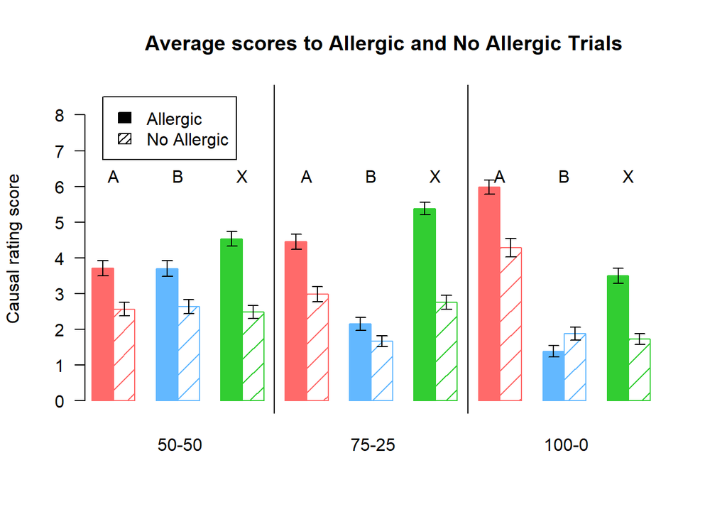

```r
par(mfrow = c(1,1))
par(las = 1)
emptyPlot(c(1,130), c(0,8.5), xaxt = "none", ymark= c(0,1,2,3,4,5,6,7,8), bty = 'n', main = "Average scores to Allergic and No Allergic Trials", xlab = "", ylab = "Causal rating score")
add_bars(x=c(0,5,15,20,30,35, 45,50,60,65,75,80, 90,95,105,110,120,125), y=c(AllergicAvg$A[AllergicAvg$Cond == "0"], NotAllergicAvg$A[NotAllergicAvg$Cond == "0"], AllergicAvg$B[AllergicAvg$Cond == "0"], NotAllergicAvg$B[NotAllergicAvg$Cond == "0"],AllergicAvg$X[AllergicAvg$Cond == "0"], NotAllergicAvg$X[NotAllergicAvg$Cond == "0"], AllergicAvg$A[AllergicAvg$Cond == "50"], NotAllergicAvg$A[NotAllergicAvg$Cond == "50"], AllergicAvg$B[AllergicAvg$Cond == "50"], NotAllergicAvg$B[NotAllergicAvg$Cond == "50"],AllergicAvg$X[AllergicAvg$Cond == "50"], NotAllergicAvg$X[NotAllergicAvg$Cond == "50"], AllergicAvg$A[AllergicAvg$Cond == "100"], NotAllergicAvg$A[NotAllergicAvg$Cond == "100"], AllergicAvg$B[AllergicAvg$Cond == "100"], NotAllergicAvg$B[NotAllergicAvg$Cond == "100"],AllergicAvg$X[AllergicAvg$Cond == "100"], NotAllergicAvg$X[NotAllergicAvg$Cond == "100"]), width = 5, col = c("indianred1", "indianred1", "steelblue1", "steelblue1", "limegreen", "limegreen"), density = c(200,6))

errorbars(x=c(0,5,15,20,30,35, 45,50,60,65,75,80, 90,95,105,110,120,125), y=c(AllergicAvg$A[AllergicAvg$Cond == "0"], NotAllergicAvg$A[NotAllergicAvg$Cond == "0"], AllergicAvg$B[AllergicAvg$Cond == "0"], NotAllergicAvg$B[NotAllergicAvg$Cond == "0"],AllergicAvg$X[AllergicAvg$Cond == "0"], NotAllergicAvg$X[NotAllergicAvg$Cond == "0"], AllergicAvg$A[AllergicAvg$Cond == "50"], NotAllergicAvg$A[NotAllergicAvg$Cond == "50"], AllergicAvg$B[AllergicAvg$Cond == "50"], NotAllergicAvg$B[NotAllergicAvg$Cond == "50"],AllergicAvg$X[AllergicAvg$Cond == "50"], NotAllergicAvg$X[NotAllergicAvg$Cond == "50"], AllergicAvg$A[AllergicAvg$Cond == "100"], NotAllergicAvg$A[NotAllergicAvg$Cond == "100"], AllergicAvg$B[AllergicAvg$Cond == "100"], NotAllergicAvg$B[NotAllergicAvg$Cond == "100"],AllergicAvg$X[AllergicAvg$Cond == "100"], NotAllergicAvg$X[NotAllergicAvg$Cond == "100"]) , top = SE , bottom = SE, add = TRUE, length = .05)

abline(v=40, col="grey2", lty = 1)
abline(v=85, col="grey2", lty = 1)
#condition text
mtext("50-50", side = 1, at = 18, line = 1)
mtext("75-25", side = 1, at = 63, line = 1)
mtext("100-0", side = 1, at = 108, line = 1)
#letters
text(x=2.5, y = 6.3, labels = "A")
text(x=47.5, y = 6.3, labels = "A")
text(x=92.5, y = 6.3, labels = "A")
text(x=17.5, y = 6.3, labels = "B")
text(x=62.5, y = 6.3, labels = "B")
text(x=107.5, y = 6.3, labels = "B")
text(x=32.5, y = 6.3, labels = "X")
text(x=77.5, y = 6.3, labels = "X")
text(x=122.5, y = 6.3, labels = "X")
legend(x=0, y = 8.5, legend =c("Allergic", "No Allergic"), density = c(200,20), col= c("indianred1"))
```

```r
SE
```

```
##  [1] 0.2096112 0.1902563 0.2162891 0.1961827 0.2027245 0.1862633 0.2069576
##  [8] 0.2144466 0.1815633 0.1510807 0.1724544 0.1946246 0.1963647 0.2523048
## [15] 0.1608095 0.1787663 0.2117673 0.1456407
```

```r
range(SE)
```

```
## [1] 0.1456407 0.2523048
```

```r
t.test(Allergic$responseR1[Allergic$Cond == "0"], NotAllergic$responseR1[NotAllergic$Cond == "0"], alternative = "two.sided", paired = FALSE) #sign, Allergic higher than Not Allergic
```

```
##
##  Welch Two Sample t-test
##
## data:  Allergic$responseR1[Allergic$Cond == "0"] and NotAllergic$responseR1[NotAllergic$Cond == "0"]
## t = 4.0501, df = 309.12, p-value = 6.48e-05
## alternative hypothesis: true difference in means is not equal to 0
## 95 percent confidence interval:
##  0.5894893 1.7035044
## sample estimates:
## mean of x mean of y
##  3.713376  2.566879
```

```r
t.test(Allergic$responseR2[Allergic$Cond == "0"], NotAllergic$responseR2[NotAllergic$Cond == "0"], alternative = "two.sided", paired = FALSE) #sign, Allergic higher than Not Allergic
```

```
##
##  Welch Two Sample t-test
##
## data:  Allergic$responseR2[Allergic$Cond == "0"] and NotAllergic$responseR2[NotAllergic$Cond == "0"]
## t = 3.6657, df = 297.99, p-value = 0.000292
## alternative hypothesis: true difference in means is not equal to 0
## 95 percent confidence interval:
##  0.4957488 1.6450668
## sample estimates:
## mean of x mean of y
##  3.701987  2.631579
```

```r
t.test(Allergic$responseR3[Allergic$Cond == "0"], NotAllergic$responseR3[NotAllergic$Cond == "0"], alternative = "two.sided", paired = FALSE) #sign, Allergic higher than Not Allergic
```

```
##
##  Welch Two Sample t-test
##
## data:  Allergic$responseR3[Allergic$Cond == "0"] and NotAllergic$responseR3[NotAllergic$Cond == "0"]
## t = 7.4272, df = 286.78, p-value = 1.275e-12
## alternative hypothesis: true difference in means is not equal to 0
## 95 percent confidence interval:
##  1.502864 2.586602
## sample estimates:
## mean of x mean of y
##  4.531034  2.486301
```

```r
t.test(Allergic$responseR1[Allergic$Cond == "50"], NotAllergic$responseR1[NotAllergic$Cond == "50"], alternative = "two.sided", paired = FALSE) #sign, Allergic higher than Not Allergic
```

```
##
##  Welch Two Sample t-test
##
## data:  Allergic$responseR1[Allergic$Cond == "50"] and NotAllergic$responseR1[NotAllergic$Cond == "50"]
## t = 4.9138, df = 308.68, p-value = 1.452e-06
## alternative hypothesis: true difference in means is not equal to 0
## 95 percent confidence interval:
##  0.8780161 2.0508507
## sample estimates:
## mean of x mean of y
##  4.451613  2.987179
```

```r
t.test(Allergic$responseR2[Allergic$Cond == "50"], NotAllergic$responseR2[NotAllergic$Cond == "50"], alternative = "two.sided", paired = FALSE) #sign, Allergic higher than Not Allergic (DIFF FROM 1)
```

```
##
##  Welch Two Sample t-test
##
## data:  Allergic$responseR2[Allergic$Cond == "50"] and NotAllergic$responseR2[NotAllergic$Cond == "50"]
## t = 2.0415, df = 289.71, p-value = 0.04211
## alternative hypothesis: true difference in means is not equal to 0
## 95 percent confidence interval:
##  0.01730665 0.94707932
## sample estimates:
## mean of x mean of y
##  2.146667  1.664474
```